# Risk Factor Analysis

## Outcome Variable

**Outcome Variable:** y_rate_haz

## Predictor Variables

**Intervention Variable:** exclfeed36

**Adjustment Set:**

- arm
- sex
- brthmon
- W_mage
- meducyrs
- feducyrs
- hhwealth_quart
- hfoodsec
- W_mhtcm
- W_mwtkg
- W_mbmi
- vagbrth
- W_birthwt
- W_birthlen
- W_nrooms
- month
- W_parity
- impfloor
- impsan
- safeh20
- delta_W_mage
- delta_meducyrs
- delta_feducyrs
- delta_hhwealth_quart
- delta_hfoodsec
- delta_W_mhtcm
- delta_W_mwtkg
- delta_W_mbmi
- delta_vagbrth
- delta_W_birthwt
- delta_W_birthlen
- delta_W_nrooms
- delta_month
- delta_W_parity
- delta_impfloor
- delta_impsan
- delta_safeh20

## Stratifying Variables

The analysis was stratified on these variable(s):

- agecat
- studyid
- country

## Data Summary

| agecat | studyid | country | exclfeed36 | n_cell | n | outcome_variable |
| --- | --- | --- | --- | --- | --- | --- |
| 0-3 months | ki0047075b-MAL-ED | BANGLADESH | 1 | 32 | 242 | y_rate_haz |
| 0-3 months | ki0047075b-MAL-ED | BANGLADESH | 0 | 210 | 242 | y_rate_haz |
| 0-3 months | ki0047075b-MAL-ED | BRAZIL | 1 | 8 | 167 | y_rate_haz |
| 0-3 months | ki0047075b-MAL-ED | BRAZIL | 0 | 159 | 167 | y_rate_haz |
| 0-3 months | ki0047075b-MAL-ED | INDIA | 1 | 4 | 181 | y_rate_haz |
| 0-3 months | ki0047075b-MAL-ED | INDIA | 0 | 177 | 181 | y_rate_haz |
| 0-3 months | ki0047075b-MAL-ED | NEPAL | 1 | 4 | 154 | y_rate_haz |
| 0-3 months | ki0047075b-MAL-ED | NEPAL | 0 | 150 | 154 | y_rate_haz |
| 0-3 months | ki0047075b-MAL-ED | PERU | 1 | 5 | 263 | y_rate_haz |
| 0-3 months | ki0047075b-MAL-ED | PERU | 0 | 258 | 263 | y_rate_haz |
| 0-3 months | ki0047075b-MAL-ED | SOUTH AFRICA | 1 | 0 | 209 | y_rate_haz |
| 0-3 months | ki0047075b-MAL-ED | SOUTH AFRICA | 0 | 209 | 209 | y_rate_haz |
| 0-3 months | ki0047075b-MAL-ED | TANZANIA, UNITED REPUBLIC OF | 1 | 3 | 223 | y_rate_haz |
| 0-3 months | ki0047075b-MAL-ED | TANZANIA, UNITED REPUBLIC OF | 0 | 220 | 223 | y_rate_haz |
| 0-3 months | ki1000108-CMC-V-BCS-2002 | INDIA | 1 | 2 | 2 | y_rate_haz |
| 0-3 months | ki1000108-CMC-V-BCS-2002 | INDIA | 0 | 0 | 2 | y_rate_haz |
| 0-3 months | ki1000108-IRC | INDIA | 1 | 0 | 4 | y_rate_haz |
| 0-3 months | ki1000108-IRC | INDIA | 0 | 4 | 4 | y_rate_haz |
| 0-3 months | ki1000109-EE | PAKISTAN | 1 | 2 | 6 | y_rate_haz |
| 0-3 months | ki1000109-EE | PAKISTAN | 0 | 4 | 6 | y_rate_haz |
| 0-3 months | ki1017093b-PROVIDE | BANGLADESH | 1 | 161 | 634 | y_rate_haz |
| 0-3 months | ki1017093b-PROVIDE | BANGLADESH | 0 | 473 | 634 | y_rate_haz |
| 0-3 months | ki1101329-Keneba | GAMBIA | 1 | 326 | 1116 | y_rate_haz |
| 0-3 months | ki1101329-Keneba | GAMBIA | 0 | 790 | 1116 | y_rate_haz |
| 0-3 months | ki1113344-GMS-Nepal | NEPAL | 1 | 372 | 465 | y_rate_haz |
| 0-3 months | ki1113344-GMS-Nepal | NEPAL | 0 | 93 | 465 | y_rate_haz |
| 0-3 months | kiGH5241-JiVitA-3 | BANGLADESH | 1 | 7572 | 9726 | y_rate_haz |
| 0-3 months | kiGH5241-JiVitA-3 | BANGLADESH | 0 | 2154 | 9726 | y_rate_haz |
| 0-3 months | kiGH5241-JiVitA-4 | BANGLADESH | 1 | 1916 | 2307 | y_rate_haz |
| 0-3 months | kiGH5241-JiVitA-4 | BANGLADESH | 0 | 391 | 2307 | y_rate_haz |

[output cut: 214 more lines]

The following strata were considered:

- agecat: 0-3 months, studyid: ki0047075b-MAL-ED, country: BANGLADESH
- agecat: 0-3 months, studyid: ki0047075b-MAL-ED, country: BRAZIL
- agecat: 0-3 months, studyid: ki0047075b-MAL-ED, country: INDIA
- agecat: 0-3 months, studyid: ki0047075b-MAL-ED, country: NEPAL
- agecat: 0-3 months, studyid: ki0047075b-MAL-ED, country: PERU
- agecat: 0-3 months, studyid: ki0047075b-MAL-ED, country: SOUTH AFRICA
- agecat: 0-3 months, studyid: ki0047075b-MAL-ED, country: TANZANIA, UNITED REPUBLIC OF
- agecat: 0-3 months, studyid: ki1000108-CMC-V-BCS-2002, country: INDIA
- agecat: 0-3 months, studyid: ki1000108-IRC, country: INDIA
- agecat: 0-3 months, studyid: ki1000109-EE, country: PAKISTAN
- agecat: 0-3 months, studyid: ki1017093b-PROVIDE, country: BANGLADESH
- agecat: 0-3 months, studyid: ki1101329-Keneba, country: GAMBIA
- agecat: 0-3 months, studyid: ki1113344-GMS-Nepal, country: NEPAL
- agecat: 0-3 months, studyid: kiGH5241-JiVitA-3, country: BANGLADESH
- agecat: 0-3 months, studyid: kiGH5241-JiVitA-4, country: BANGLADESH
- agecat: 12-15 months, studyid: ki0047075b-MAL-ED, country: BANGLADESH
- agecat: 12-15 months, studyid: ki0047075b-MAL-ED, country: BRAZIL
- agecat: 12-15 months, studyid: ki0047075b-MAL-ED, country: INDIA
- agecat: 12-15 months, studyid: ki0047075b-MAL-ED, country: NEPAL
- agecat: 12-15 months, studyid: ki0047075b-MAL-ED, country: PERU
- agecat: 12-15 months, studyid: ki0047075b-MAL-ED, country: SOUTH AFRICA
- agecat: 12-15 months, studyid: ki0047075b-MAL-ED, country: TANZANIA, UNITED REPUBLIC OF
- agecat: 12-15 months, studyid: ki1000108-CMC-V-BCS-2002, country: INDIA
- agecat: 12-15 months, studyid: ki1000108-IRC, country: INDIA
- agecat: 12-15 months, studyid: ki1000109-EE, country: PAKISTAN
- agecat: 12-15 months, studyid: ki1000304b-SAS-FoodSuppl, country: INDIA
- agecat: 12-15 months, studyid: ki1017093b-PROVIDE, country: BANGLADESH
- agecat: 12-15 months, studyid: ki1101329-Keneba, country: GAMBIA
- agecat: 12-15 months, studyid: ki1113344-GMS-Nepal, country: NEPAL
- agecat: 12-15 months, studyid: ki1148112-LCNI-5, country: MALAWI
- agecat: 12-15 months, studyid: kiGH5241-JiVitA-4, country: BANGLADESH
- agecat: 15-18 months, studyid: ki0047075b-MAL-ED, country: BANGLADESH
- agecat: 15-18 months, studyid: ki0047075b-MAL-ED, country: BRAZIL
- agecat: 15-18 months, studyid: ki0047075b-MAL-ED, country: INDIA
- agecat: 15-18 months, studyid: ki0047075b-MAL-ED, country: NEPAL
- agecat: 15-18 months, studyid: ki0047075b-MAL-ED, country: PERU
- agecat: 15-18 months, studyid: ki0047075b-MAL-ED, country: SOUTH AFRICA
- agecat: 15-18 months, studyid: ki0047075b-MAL-ED, country: TANZANIA, UNITED REPUBLIC OF
- agecat: 15-18 months, studyid: ki1000108-CMC-V-BCS-2002, country: INDIA
- agecat: 15-18 months, studyid: ki1000108-IRC, country: INDIA
- agecat: 15-18 months, studyid: ki1000109-EE, country: PAKISTAN
- agecat: 15-18 months, studyid: ki1000304b-SAS-FoodSuppl, country: INDIA
- agecat: 15-18 months, studyid: ki1017093b-PROVIDE, country: BANGLADESH
- agecat: 15-18 months, studyid: ki1101329-Keneba, country: GAMBIA
- agecat: 15-18 months, studyid: ki1113344-GMS-Nepal, country: NEPAL
- agecat: 15-18 months, studyid: ki1148112-LCNI-5, country: MALAWI
- agecat: 15-18 months, studyid: kiGH5241-JiVitA-4, country: BANGLADESH
- agecat: 18-21 months, studyid: ki0047075b-MAL-ED, country: BANGLADESH
- agecat: 18-21 months, studyid: ki0047075b-MAL-ED, country: BRAZIL
- agecat: 18-21 months, studyid: ki0047075b-MAL-ED, country: INDIA
- agecat: 18-21 months, studyid: ki0047075b-MAL-ED, country: NEPAL
- agecat: 18-21 months, studyid: ki0047075b-MAL-ED, country: PERU
- agecat: 18-21 months, studyid: ki0047075b-MAL-ED, country: SOUTH AFRICA
- agecat: 18-21 months, studyid: ki0047075b-MAL-ED, country: TANZANIA, UNITED REPUBLIC OF
- agecat: 18-21 months, studyid: ki1000108-CMC-V-BCS-2002, country: INDIA
- agecat: 18-21 months, studyid: ki1000108-IRC, country: INDIA
- agecat: 18-21 months, studyid: ki1000109-EE, country: PAKISTAN
- agecat: 18-21 months, studyid: ki1017093b-PROVIDE, country: BANGLADESH
- agecat: 18-21 months, studyid: ki1101329-Keneba, country: GAMBIA
- agecat: 18-21 months, studyid: ki1113344-GMS-Nepal, country: NEPAL
- agecat: 18-21 months, studyid: ki1148112-LCNI-5, country: MALAWI
- agecat: 21-24 months, studyid: ki0047075b-MAL-ED, country: BANGLADESH
- agecat: 21-24 months, studyid: ki0047075b-MAL-ED, country: BRAZIL
- agecat: 21-24 months, studyid: ki0047075b-MAL-ED, country: INDIA
- agecat: 21-24 months, studyid: ki0047075b-MAL-ED, country: NEPAL
- agecat: 21-24 months, studyid: ki0047075b-MAL-ED, country: PERU
- agecat: 21-24 months, studyid: ki0047075b-MAL-ED, country: SOUTH AFRICA
- agecat: 21-24 months, studyid: ki0047075b-MAL-ED, country: TANZANIA, UNITED REPUBLIC OF
- agecat: 21-24 months, studyid: ki1000108-CMC-V-BCS-2002, country: INDIA
- agecat: 21-24 months, studyid: ki1000108-IRC, country: INDIA
- agecat: 21-24 months, studyid: ki1000109-EE, country: PAKISTAN
- agecat: 21-24 months, studyid: ki1017093b-PROVIDE, country: BANGLADESH
- agecat: 21-24 months, studyid: ki1101329-Keneba, country: GAMBIA
- agecat: 21-24 months, studyid: ki1113344-GMS-Nepal, country: NEPAL
- agecat: 21-24 months, studyid: ki1148112-LCNI-5, country: MALAWI
- agecat: 3-6 months, studyid: ki0047075b-MAL-ED, country: BANGLADESH
- agecat: 3-6 months, studyid: ki0047075b-MAL-ED, country: BRAZIL
- agecat: 3-6 months, studyid: ki0047075b-MAL-ED, country: INDIA
- agecat: 3-6 months, studyid: ki0047075b-MAL-ED, country: NEPAL
- agecat: 3-6 months, studyid: ki0047075b-MAL-ED, country: PERU
- agecat: 3-6 months, studyid: ki0047075b-MAL-ED, country: SOUTH AFRICA
- agecat: 3-6 months, studyid: ki0047075b-MAL-ED, country: TANZANIA, UNITED REPUBLIC OF
- agecat: 3-6 months, studyid: ki1000108-CMC-V-BCS-2002, country: INDIA
- agecat: 3-6 months, studyid: ki1000108-IRC, country: INDIA
- agecat: 3-6 months, studyid: ki1000109-EE, country: PAKISTAN
- agecat: 3-6 months, studyid: ki1017093b-PROVIDE, country: BANGLADESH
- agecat: 3-6 months, studyid: ki1101329-Keneba, country: GAMBIA
- agecat: 3-6 months, studyid: ki1113344-GMS-Nepal, country: NEPAL
- agecat: 3-6 months, studyid: kiGH5241-JiVitA-3, country: BANGLADESH
- agecat: 3-6 months, studyid: kiGH5241-JiVitA-4, country: BANGLADESH
- agecat: 6-9 months, studyid: ki0047075b-MAL-ED, country: BANGLADESH
- agecat: 6-9 months, studyid: ki0047075b-MAL-ED, country: BRAZIL
- agecat: 6-9 months, studyid: ki0047075b-MAL-ED, country: INDIA
- agecat: 6-9 months, studyid: ki0047075b-MAL-ED, country: NEPAL
- agecat: 6-9 months, studyid: ki0047075b-MAL-ED, country: PERU
- agecat: 6-9 months, studyid: ki0047075b-MAL-ED, country: SOUTH AFRICA
- agecat: 6-9 months, studyid: ki0047075b-MAL-ED, country: TANZANIA, UNITED REPUBLIC OF
- agecat: 6-9 months, studyid: ki1000108-CMC-V-BCS-2002, country: INDIA
- agecat: 6-9 months, studyid: ki1000108-IRC, country: INDIA
- agecat: 6-9 months, studyid: ki1000109-EE, country: PAKISTAN
- agecat: 6-9 months, studyid: ki1000304b-SAS-FoodSuppl, country: INDIA
- agecat: 6-9 months, studyid: ki1017093b-PROVIDE, country: BANGLADESH
- agecat: 6-9 months, studyid: ki1101329-Keneba, country: GAMBIA
- agecat: 6-9 months, studyid: ki1113344-GMS-Nepal, country: NEPAL
- agecat: 6-9 months, studyid: ki1148112-LCNI-5, country: MALAWI
- agecat: 6-9 months, studyid: kiGH5241-JiVitA-4, country: BANGLADESH
- agecat: 9-12 months, studyid: ki0047075b-MAL-ED, country: BANGLADESH
- agecat: 9-12 months, studyid: ki0047075b-MAL-ED, country: BRAZIL
- agecat: 9-12 months, studyid: ki0047075b-MAL-ED, country: INDIA
- agecat: 9-12 months, studyid: ki0047075b-MAL-ED, country: NEPAL
- agecat: 9-12 months, studyid: ki0047075b-MAL-ED, country: PERU
- agecat: 9-12 months, studyid: ki0047075b-MAL-ED, country: SOUTH AFRICA
- agecat: 9-12 months, studyid: ki0047075b-MAL-ED, country: TANZANIA, UNITED REPUBLIC OF
- agecat: 9-12 months, studyid: ki1000108-CMC-V-BCS-2002, country: INDIA
- agecat: 9-12 months, studyid: ki1000108-IRC, country: INDIA
- agecat: 9-12 months, studyid: ki1000109-EE, country: PAKISTAN
- agecat: 9-12 months, studyid: ki1000304b-SAS-FoodSuppl, country: INDIA
- agecat: 9-12 months, studyid: ki1017093b-PROVIDE, country: BANGLADESH
- agecat: 9-12 months, studyid: ki1101329-Keneba, country: GAMBIA
- agecat: 9-12 months, studyid: ki1113344-GMS-Nepal, country: NEPAL
- agecat: 9-12 months, studyid: ki1148112-LCNI-5, country: MALAWI
- agecat: 9-12 months, studyid: kiGH5241-JiVitA-4, country: BANGLADESH

### Dropped Strata

Some strata were dropped due to rare outcomes:

- agecat: 0-3 months, studyid: ki0047075b-MAL-ED, country: INDIA
- agecat: 0-3 months, studyid: ki0047075b-MAL-ED, country: NEPAL
- agecat: 0-3 months, studyid: ki0047075b-MAL-ED, country: SOUTH AFRICA
- agecat: 0-3 months, studyid: ki0047075b-MAL-ED, country: TANZANIA, UNITED REPUBLIC OF
- agecat: 0-3 months, studyid: ki1000108-CMC-V-BCS-2002, country: INDIA
- agecat: 0-3 months, studyid: ki1000108-IRC, country: INDIA
- agecat: 0-3 months, studyid: ki1000109-EE, country: PAKISTAN
- agecat: 3-6 months, studyid: ki0047075b-MAL-ED, country: NEPAL
- agecat: 3-6 months, studyid: ki0047075b-MAL-ED, country: SOUTH AFRICA
- agecat: 3-6 months, studyid: ki0047075b-MAL-ED, country: TANZANIA, UNITED REPUBLIC OF
- agecat: 3-6 months, studyid: ki1000108-CMC-V-BCS-2002, country: INDIA
- agecat: 3-6 months, studyid: ki1000108-IRC, country: INDIA
- agecat: 3-6 months, studyid: ki1000109-EE, country: PAKISTAN
- agecat: 6-9 months, studyid: ki0047075b-MAL-ED, country: NEPAL
- agecat: 6-9 months, studyid: ki0047075b-MAL-ED, country: SOUTH AFRICA
- agecat: 6-9 months, studyid: ki0047075b-MAL-ED, country: TANZANIA, UNITED REPUBLIC OF
- agecat: 6-9 months, studyid: ki1000108-CMC-V-BCS-2002, country: INDIA
- agecat: 6-9 months, studyid: ki1000108-IRC, country: INDIA
- agecat: 6-9 months, studyid: ki1000109-EE, country: PAKISTAN
- agecat: 6-9 months, studyid: ki1000304b-SAS-FoodSuppl, country: INDIA
- agecat: 9-12 months, studyid: ki0047075b-MAL-ED, country: NEPAL
- agecat: 9-12 months, studyid: ki0047075b-MAL-ED, country: SOUTH AFRICA
- agecat: 9-12 months, studyid: ki0047075b-MAL-ED, country: TANZANIA, UNITED REPUBLIC OF
- agecat: 9-12 months, studyid: ki1000108-CMC-V-BCS-2002, country: INDIA
- agecat: 9-12 months, studyid: ki1000108-IRC, country: INDIA
- agecat: 9-12 months, studyid: ki1000109-EE, country: PAKISTAN
- agecat: 9-12 months, studyid: ki1000304b-SAS-FoodSuppl, country: INDIA
- agecat: 12-15 months, studyid: ki0047075b-MAL-ED, country: NEPAL
- agecat: 12-15 months, studyid: ki0047075b-MAL-ED, country: SOUTH AFRICA
- agecat: 12-15 months, studyid: ki0047075b-MAL-ED, country: TANZANIA, UNITED REPUBLIC OF
- agecat: 12-15 months, studyid: ki1000108-CMC-V-BCS-2002, country: INDIA
- agecat: 12-15 months, studyid: ki1000108-IRC, country: INDIA
- agecat: 12-15 months, studyid: ki1000109-EE, country: PAKISTAN
- agecat: 12-15 months, studyid: ki1000304b-SAS-FoodSuppl, country: INDIA
- agecat: 12-15 months, studyid: ki1148112-LCNI-5, country: MALAWI
- agecat: 15-18 months, studyid: ki0047075b-MAL-ED, country: NEPAL
- agecat: 15-18 months, studyid: ki0047075b-MAL-ED, country: SOUTH AFRICA
- agecat: 15-18 months, studyid: ki0047075b-MAL-ED, country: TANZANIA, UNITED REPUBLIC OF
- agecat: 15-18 months, studyid: ki1000108-CMC-V-BCS-2002, country: INDIA
- agecat: 15-18 months, studyid: ki1000108-IRC, country: INDIA
- agecat: 15-18 months, studyid: ki1000109-EE, country: PAKISTAN
- agecat: 15-18 months, studyid: ki1000304b-SAS-FoodSuppl, country: INDIA
- agecat: 15-18 months, studyid: ki1148112-LCNI-5, country: MALAWI
- agecat: 18-21 months, studyid: ki0047075b-MAL-ED, country: NEPAL
- agecat: 18-21 months, studyid: ki0047075b-MAL-ED, country: PERU
- agecat: 18-21 months, studyid: ki0047075b-MAL-ED, country: SOUTH AFRICA
- agecat: 18-21 months, studyid: ki0047075b-MAL-ED, country: TANZANIA, UNITED REPUBLIC OF
- agecat: 18-21 months, studyid: ki1000108-CMC-V-BCS-2002, country: INDIA
- agecat: 18-21 months, studyid: ki1000108-IRC, country: INDIA
- agecat: 18-21 months, studyid: ki1000109-EE, country: PAKISTAN
- agecat: 21-24 months, studyid: ki0047075b-MAL-ED, country: NEPAL
- agecat: 21-24 months, studyid: ki0047075b-MAL-ED, country: PERU
- agecat: 21-24 months, studyid: ki0047075b-MAL-ED, country: SOUTH AFRICA
- agecat: 21-24 months, studyid: ki0047075b-MAL-ED, country: TANZANIA, UNITED REPUBLIC OF
- agecat: 21-24 months, studyid: ki1000108-CMC-V-BCS-2002, country: INDIA
- agecat: 21-24 months, studyid: ki1000108-IRC, country: INDIA
- agecat: 21-24 months, studyid: ki1000109-EE, country: PAKISTAN

## Methods Detail

We’re interested in the causal parameters $E[Y_a]$ for all values of $a \in \mathcal{A}$. These parameters represent the mean outcome if, possibly contrary to fact, we intervened to set all units to have $A=a$. Under the randomization and positivity assumptions, these are identified by the statistical parameters $\psi_a=E_W[E_{Y|A,W}(Y|A=a,W)]$. In addition, we’re interested in the mean of $Y$, $E[Y]$ under no intervention (the observed mean). We will estimate these parameters by using SuperLearner to fit the relevant likelihood factors – $E_{Y|A,W}(Y|A=a,W)$ and $p(A=a|W)$, and then updating our likelihood fit using a joint TMLE.

For unadjusted analyses ($W=\{\}$), initial likelihoods were estimated using Lrnr_glm to estimate the simple $E(Y|A)$ and Lrnr_mean to estimate $p(A)$. For adjusted analyses, a small library containing Lrnr_glmnet, Lrnr_xgboost, and Lrnr_mean was used.

Having estimated these parameters, we will then use the delta method to estimate relative risks and attributable risks relative to a prespecified baseline level of $A$.

# Results Detail

## Results Plots

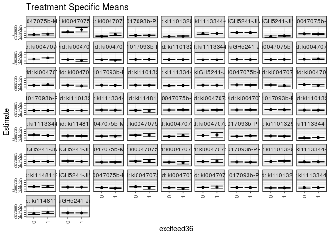

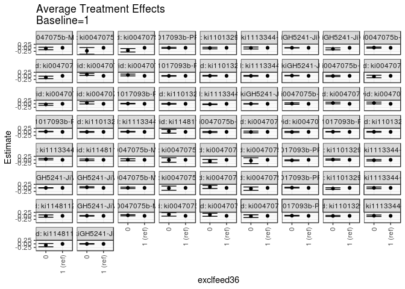

[figure not shown]

## Results Table

### Parameter: TSM

| agecat | studyid | country | intervention_level | baseline_level | estimate | ci_lower | ci_upper |
| --- | --- | --- | --- | --- | --- | --- | --- |
| 0-3 months | ki0047075b-MAL-ED | BANGLADESH | 1 | NA | -0.0783241 | -0.1595088 | 0.0028606 |
| 0-3 months | ki0047075b-MAL-ED | BANGLADESH | 0 | NA | -0.1247809 | -0.1616224 | -0.0879395 |
| 0-3 months | ki0047075b-MAL-ED | BRAZIL | 1 | NA | 0.3460294 | 0.1166038 | 0.5754549 |
| 0-3 months | ki0047075b-MAL-ED | BRAZIL | 0 | NA | 0.1287992 | 0.0709434 | 0.1866551 |
| 0-3 months | ki0047075b-MAL-ED | PERU | 1 | NA | -0.0942168 | -0.2126675 | 0.0242339 |
| 0-3 months | ki0047075b-MAL-ED | PERU | 0 | NA | -0.2685187 | -0.3031690 | -0.2338684 |
| 0-3 months | ki1017093b-PROVIDE | BANGLADESH | 1 | NA | -0.1864168 | -0.2179521 | -0.1548814 |
| 0-3 months | ki1017093b-PROVIDE | BANGLADESH | 0 | NA | -0.1886799 | -0.2093375 | -0.1680222 |
| 0-3 months | ki1101329-Keneba | GAMBIA | 1 | NA | -0.2712913 | -0.3178015 | -0.2247811 |
| 0-3 months | ki1101329-Keneba | GAMBIA | 0 | NA | -0.2880798 | -0.3191622 | -0.2569973 |
| 0-3 months | ki1113344-GMS-Nepal | NEPAL | 1 | NA | -0.0213199 | -0.0498885 | 0.0072487 |
| 0-3 months | ki1113344-GMS-Nepal | NEPAL | 0 | NA | -0.0343428 | -0.0986927 | 0.0300070 |
| 0-3 months | kiGH5241-JiVitA-3 | BANGLADESH | 1 | NA | 0.0541110 | 0.0471993 | 0.0610227 |
| 0-3 months | kiGH5241-JiVitA-3 | BANGLADESH | 0 | NA | 0.0562097 | 0.0440773 | 0.0683421 |
| 0-3 months | kiGH5241-JiVitA-4 | BANGLADESH | 1 | NA | -0.2354191 | -0.2643185 | -0.2065198 |
| 0-3 months | kiGH5241-JiVitA-4 | BANGLADESH | 0 | NA | -0.3080286 | -0.3737115 | -0.2423457 |
| 3-6 months | ki0047075b-MAL-ED | BANGLADESH | 1 | NA | -0.0301600 | -0.1011534 | 0.0408333 |
| 3-6 months | ki0047075b-MAL-ED | BANGLADESH | 0 | NA | -0.0245595 | -0.0490656 | -0.0000533 |
| 3-6 months | ki0047075b-MAL-ED | BRAZIL | 1 | NA | 0.0687802 | -0.0867977 | 0.2243581 |
| 3-6 months | ki0047075b-MAL-ED | BRAZIL | 0 | NA | 0.0568615 | 0.0191452 | 0.0945777 |
| 3-6 months | ki0047075b-MAL-ED | INDIA | 1 | NA | 0.0473608 | -0.0695552 | 0.1642768 |
| 3-6 months | ki0047075b-MAL-ED | INDIA | 0 | NA | -0.0431444 | -0.0731638 | -0.0131251 |
| 3-6 months | ki0047075b-MAL-ED | PERU | 1 | NA | 0.0822238 | -0.1223318 | 0.2867794 |
| 3-6 months | ki0047075b-MAL-ED | PERU | 0 | NA | 0.0244477 | -0.0071690 | 0.0560644 |
| 3-6 months | ki1017093b-PROVIDE | BANGLADESH | 1 | NA | -0.0010727 | -0.0312209 | 0.0290756 |
| 3-6 months | ki1017093b-PROVIDE | BANGLADESH | 0 | NA | -0.0333183 | -0.0514546 | -0.0151821 |
| 3-6 months | ki1101329-Keneba | GAMBIA | 1 | NA | -0.0322366 | -0.0679387 | 0.0034655 |
| 3-6 months | ki1101329-Keneba | GAMBIA | 0 | NA | -0.0150918 | -0.0383939 | 0.0082102 |
| 3-6 months | ki1113344-GMS-Nepal | NEPAL | 1 | NA | -0.1587050 | -0.1792404 | -0.1381696 |
| 3-6 months | ki1113344-GMS-Nepal | NEPAL | 0 | NA | -0.1862514 | -0.2325710 | -0.1399318 |

[output cut: 100 more lines]

### Parameter: E(Y)

| agecat | studyid | country | intervention_level | baseline_level | estimate | ci_lower | ci_upper |
| --- | --- | --- | --- | --- | --- | --- | --- |
| 0-3 months | ki0047075b-MAL-ED | BANGLADESH | NA | NA | -0.1219910 | -0.1558661 | -0.0881159 |
| 0-3 months | ki0047075b-MAL-ED | BRAZIL | NA | NA | 0.1392055 | 0.0825938 | 0.1958172 |
| 0-3 months | ki0047075b-MAL-ED | PERU | NA | NA | -0.2652050 | -0.2992408 | -0.2311692 |
| 0-3 months | ki1017093b-PROVIDE | BANGLADESH | NA | NA | -0.1881464 | -0.2054815 | -0.1708113 |
| 0-3 months | ki1101329-Keneba | GAMBIA | NA | NA | -0.2813600 | -0.3072816 | -0.2554385 |
| 0-3 months | ki1113344-GMS-Nepal | NEPAL | NA | NA | -0.0244364 | -0.0506014 | 0.0017286 |
| 0-3 months | kiGH5241-JiVitA-3 | BANGLADESH | NA | NA | 0.0545297 | 0.0481073 | 0.0609521 |
| 0-3 months | kiGH5241-JiVitA-4 | BANGLADESH | NA | NA | -0.2476806 | -0.2745201 | -0.2208411 |
| 3-6 months | ki0047075b-MAL-ED | BANGLADESH | NA | NA | -0.0232296 | -0.0468728 | 0.0004136 |
| 3-6 months | ki0047075b-MAL-ED | BRAZIL | NA | NA | 0.0597292 | 0.0232017 | 0.0962566 |
| 3-6 months | ki0047075b-MAL-ED | INDIA | NA | NA | -0.0395718 | -0.0688631 | -0.0102806 |
| 3-6 months | ki0047075b-MAL-ED | PERU | NA | NA | 0.0257461 | -0.0055184 | 0.0570106 |
| 3-6 months | ki1017093b-PROVIDE | BANGLADESH | NA | NA | -0.0259615 | -0.0417668 | -0.0101562 |
| 3-6 months | ki1101329-Keneba | GAMBIA | NA | NA | -0.0181994 | -0.0377516 | 0.0013528 |
| 3-6 months | ki1113344-GMS-Nepal | NEPAL | NA | NA | -0.1619144 | -0.1807661 | -0.1430628 |
| 3-6 months | kiGH5241-JiVitA-3 | BANGLADESH | NA | NA | -0.0062187 | -0.0128267 | 0.0003893 |
| 3-6 months | kiGH5241-JiVitA-4 | BANGLADESH | NA | NA | -0.0104148 | -0.0243612 | 0.0035317 |
| 6-9 months | ki0047075b-MAL-ED | BANGLADESH | NA | NA | -0.0700232 | -0.0872813 | -0.0527650 |
| 6-9 months | ki0047075b-MAL-ED | BRAZIL | NA | NA | 0.0087834 | -0.0260798 | 0.0436466 |
| 6-9 months | ki0047075b-MAL-ED | INDIA | NA | NA | -0.0730606 | -0.0957376 | -0.0503836 |
| 6-9 months | ki0047075b-MAL-ED | PERU | NA | NA | -0.0335784 | -0.0576919 | -0.0094649 |
| 6-9 months | ki1017093b-PROVIDE | BANGLADESH | NA | NA | -0.0614264 | -0.0722690 | -0.0505838 |
| 6-9 months | ki1101329-Keneba | GAMBIA | NA | NA | -0.0112500 | -0.0357999 | 0.0132998 |
| 6-9 months | ki1113344-GMS-Nepal | NEPAL | NA | NA | -0.0452273 | -0.0630261 | -0.0274285 |
| 6-9 months | ki1148112-LCNI-5 | MALAWI | NA | NA | 0.0095862 | -0.0174314 | 0.0366037 |
| 6-9 months | kiGH5241-JiVitA-4 | BANGLADESH | NA | NA | -0.0285349 | -0.0378750 | -0.0191949 |
| 9-12 months | ki0047075b-MAL-ED | BANGLADESH | NA | NA | -0.0872054 | -0.1033675 | -0.0710433 |
| 9-12 months | ki0047075b-MAL-ED | BRAZIL | NA | NA | 0.0081784 | -0.0226414 | 0.0389982 |
| 9-12 months | ki0047075b-MAL-ED | INDIA | NA | NA | -0.0918936 | -0.1079066 | -0.0758806 |
| 9-12 months | ki0047075b-MAL-ED | PERU | NA | NA | -0.0419261 | -0.0633861 | -0.0204661 |
| 9-12 months | ki1017093b-PROVIDE | BANGLADESH | NA | NA | -0.0628687 | -0.0738539 | -0.0518835 |
| 9-12 months | ki1101329-Keneba | GAMBIA | NA | NA | -0.0987979 | -0.1174339 | -0.0801618 |
| 9-12 months | ki1113344-GMS-Nepal | NEPAL | NA | NA | -0.0800260 | -0.0943928 | -0.0656593 |
| 9-12 months | ki1148112-LCNI-5 | MALAWI | NA | NA | -0.1052774 | -0.1637460 | -0.0468087 |
| 9-12 months | kiGH5241-JiVitA-4 | BANGLADESH | NA | NA | -0.0531058 | -0.0612606 | -0.0449509 |
| 12-15 months | ki0047075b-MAL-ED | BANGLADESH | NA | NA | -0.0557123 | -0.0712495 | -0.0401751 |
| 12-15 months | ki0047075b-MAL-ED | BRAZIL | NA | NA | -0.0030430 | -0.0256176 | 0.0195316 |
| 12-15 months | ki0047075b-MAL-ED | INDIA | NA | NA | -0.0576039 | -0.0729359 | -0.0422719 |
| 12-15 months | ki0047075b-MAL-ED | PERU | NA | NA | -0.0653532 | -0.0832313 | -0.0474751 |
| 12-15 months | ki1017093b-PROVIDE | BANGLADESH | NA | NA | -0.0408493 | -0.0509622 | -0.0307364 |
| 12-15 months | ki1101329-Keneba | GAMBIA | NA | NA | -0.0513458 | -0.0638293 | -0.0388624 |
| 12-15 months | ki1113344-GMS-Nepal | NEPAL | NA | NA | -0.0707654 | -0.0805279 | -0.0610030 |
| 12-15 months | kiGH5241-JiVitA-4 | BANGLADESH | NA | NA | -0.0465550 | -0.0533118 | -0.0397982 |
| 15-18 months | ki0047075b-MAL-ED | BANGLADESH | NA | NA | -0.0457943 | -0.0592710 | -0.0323176 |
| 15-18 months | ki0047075b-MAL-ED | BRAZIL | NA | NA | -0.0203422 | -0.0414264 | 0.0007419 |
| 15-18 months | ki0047075b-MAL-ED | INDIA | NA | NA | -0.0367528 | -0.0495674 | -0.0239382 |
| 15-18 months | ki0047075b-MAL-ED | PERU | NA | NA | -0.0360565 | -0.0515481 | -0.0205649 |
| 15-18 months | ki1017093b-PROVIDE | BANGLADESH | NA | NA | -0.0375600 | -0.0463196 | -0.0288004 |
| 15-18 months | ki1101329-Keneba | GAMBIA | NA | NA | -0.0329424 | -0.0454411 | -0.0204438 |
| 15-18 months | ki1113344-GMS-Nepal | NEPAL | NA | NA | -0.0676012 | -0.0796397 | -0.0555626 |
| 15-18 months | kiGH5241-JiVitA-4 | BANGLADESH | NA | NA | -0.0333707 | -0.0399958 | -0.0267456 |
| 18-21 months | ki0047075b-MAL-ED | BANGLADESH | NA | NA | -0.0155219 | -0.0271478 | -0.0038959 |
| 18-21 months | ki0047075b-MAL-ED | BRAZIL | NA | NA | -0.0203590 | -0.0449122 | 0.0041942 |
| 18-21 months | ki0047075b-MAL-ED | INDIA | NA | NA | 0.0047911 | -0.0066468 | 0.0162289 |
| 18-21 months | ki1017093b-PROVIDE | BANGLADESH | NA | NA | -0.0109038 | -0.0190771 | -0.0027305 |
| 18-21 months | ki1101329-Keneba | GAMBIA | NA | NA | -0.0215104 | -0.0346731 | -0.0083477 |
| 18-21 months | ki1113344-GMS-Nepal | NEPAL | NA | NA | 0.0158061 | 0.0032947 | 0.0283174 |
| 18-21 months | ki1148112-LCNI-5 | MALAWI | NA | NA | -0.0092283 | -0.0423286 | 0.0238719 |
| 21-24 months | ki0047075b-MAL-ED | BANGLADESH | NA | NA | 0.0256182 | 0.0134577 | 0.0377787 |
| 21-24 months | ki0047075b-MAL-ED | BRAZIL | NA | NA | 0.0164870 | 0.0004862 | 0.0324878 |
| 21-24 months | ki0047075b-MAL-ED | INDIA | NA | NA | 0.0301809 | 0.0192922 | 0.0410697 |
| 21-24 months | ki1017093b-PROVIDE | BANGLADESH | NA | NA | 0.0463714 | 0.0377102 | 0.0550326 |
| 21-24 months | ki1101329-Keneba | GAMBIA | NA | NA | 0.0185345 | 0.0063004 | 0.0307686 |
| 21-24 months | ki1113344-GMS-Nepal | NEPAL | NA | NA | 0.0449374 | 0.0286985 | 0.0611763 |
| 21-24 months | ki1148112-LCNI-5 | MALAWI | NA | NA | -0.0116248 | -0.0336145 | 0.0103649 |

### Parameter: ATE

| agecat | studyid | country | intervention_level | baseline_level | estimate | ci_lower | ci_upper |
| --- | --- | --- | --- | --- | --- | --- | --- |
| 0-3 months | ki0047075b-MAL-ED | BANGLADESH | 1 | 1 | 0.0000000 | 0.0000000 | 0.0000000 |
| 0-3 months | ki0047075b-MAL-ED | BANGLADESH | 0 | 1 | -0.0464568 | -0.1354035 | 0.0424898 |
| 0-3 months | ki0047075b-MAL-ED | BRAZIL | 1 | 1 | 0.0000000 | 0.0000000 | 0.0000000 |
| 0-3 months | ki0047075b-MAL-ED | BRAZIL | 0 | 1 | -0.2172301 | -0.4538382 | 0.0193780 |
| 0-3 months | ki0047075b-MAL-ED | PERU | 1 | 1 | 0.0000000 | 0.0000000 | 0.0000000 |
| 0-3 months | ki0047075b-MAL-ED | PERU | 0 | 1 | -0.1743019 | -0.2977168 | -0.0508871 |
| 0-3 months | ki1017093b-PROVIDE | BANGLADESH | 1 | 1 | 0.0000000 | 0.0000000 | 0.0000000 |
| 0-3 months | ki1017093b-PROVIDE | BANGLADESH | 0 | 1 | -0.0022631 | -0.0399935 | 0.0354673 |
| 0-3 months | ki1101329-Keneba | GAMBIA | 1 | 1 | 0.0000000 | 0.0000000 | 0.0000000 |
| 0-3 months | ki1101329-Keneba | GAMBIA | 0 | 1 | -0.0167885 | -0.0725568 | 0.0389799 |
| 0-3 months | ki1113344-GMS-Nepal | NEPAL | 1 | 1 | 0.0000000 | 0.0000000 | 0.0000000 |
| 0-3 months | ki1113344-GMS-Nepal | NEPAL | 0 | 1 | -0.0130230 | -0.0834588 | 0.0574129 |
| 0-3 months | kiGH5241-JiVitA-3 | BANGLADESH | 1 | 1 | 0.0000000 | 0.0000000 | 0.0000000 |
| 0-3 months | kiGH5241-JiVitA-3 | BANGLADESH | 0 | 1 | 0.0020987 | -0.0107535 | 0.0149508 |
| 0-3 months | kiGH5241-JiVitA-4 | BANGLADESH | 1 | 1 | 0.0000000 | 0.0000000 | 0.0000000 |
| 0-3 months | kiGH5241-JiVitA-4 | BANGLADESH | 0 | 1 | -0.0726094 | -0.1433509 | -0.0018679 |
| 3-6 months | ki0047075b-MAL-ED | BANGLADESH | 1 | 1 | 0.0000000 | 0.0000000 | 0.0000000 |
| 3-6 months | ki0047075b-MAL-ED | BANGLADESH | 0 | 1 | 0.0056006 | -0.0697687 | 0.0809699 |
| 3-6 months | ki0047075b-MAL-ED | BRAZIL | 1 | 1 | 0.0000000 | 0.0000000 | 0.0000000 |
| 3-6 months | ki0047075b-MAL-ED | BRAZIL | 0 | 1 | -0.0119187 | -0.1717935 | 0.1479561 |
| 3-6 months | ki0047075b-MAL-ED | INDIA | 1 | 1 | 0.0000000 | 0.0000000 | 0.0000000 |
| 3-6 months | ki0047075b-MAL-ED | INDIA | 0 | 1 | -0.0905052 | -0.2112135 | 0.0302032 |
| 3-6 months | ki0047075b-MAL-ED | PERU | 1 | 1 | 0.0000000 | 0.0000000 | 0.0000000 |
| 3-6 months | ki0047075b-MAL-ED | PERU | 0 | 1 | -0.0577760 | -0.2647606 | 0.1492085 |
| 3-6 months | ki1017093b-PROVIDE | BANGLADESH | 1 | 1 | 0.0000000 | 0.0000000 | 0.0000000 |
| 3-6 months | ki1017093b-PROVIDE | BANGLADESH | 0 | 1 | -0.0322456 | -0.0668275 | 0.0023362 |
| 3-6 months | ki1101329-Keneba | GAMBIA | 1 | 1 | 0.0000000 | 0.0000000 | 0.0000000 |
| 3-6 months | ki1101329-Keneba | GAMBIA | 0 | 1 | 0.0171448 | -0.0253540 | 0.0596435 |
| 3-6 months | ki1113344-GMS-Nepal | NEPAL | 1 | 1 | 0.0000000 | 0.0000000 | 0.0000000 |
| 3-6 months | ki1113344-GMS-Nepal | NEPAL | 0 | 1 | -0.0275464 | -0.0782914 | 0.0231987 |

[output cut: 100 more lines]

### Parameter: PAR

| agecat | studyid | country | intervention_level | baseline_level | estimate | ci_lower | ci_upper |
| --- | --- | --- | --- | --- | --- | --- | --- |
| 0-3 months | ki0047075b-MAL-ED | BANGLADESH | 1 | NA | -0.0436669 | -0.1223620 | 0.0350281 |
| 0-3 months | ki0047075b-MAL-ED | BRAZIL | 1 | NA | -0.2068239 | -0.4322080 | 0.0185602 |
| 0-3 months | ki0047075b-MAL-ED | PERU | 1 | NA | -0.1709882 | -0.2913522 | -0.0506243 |
| 0-3 months | ki1017093b-PROVIDE | BANGLADESH | 1 | NA | -0.0017297 | -0.0299103 | 0.0264510 |
| 0-3 months | ki1101329-Keneba | GAMBIA | 1 | NA | -0.0100687 | -0.0496762 | 0.0295388 |
| 0-3 months | ki1113344-GMS-Nepal | NEPAL | 1 | NA | -0.0031165 | -0.0171614 | 0.0109283 |
| 0-3 months | kiGH5241-JiVitA-3 | BANGLADESH | 1 | NA | 0.0004187 | -0.0024213 | 0.0032587 |
| 0-3 months | kiGH5241-JiVitA-4 | BANGLADESH | 1 | NA | -0.0122614 | -0.0239436 | -0.0005793 |
| 3-6 months | ki0047075b-MAL-ED | BANGLADESH | 1 | NA | 0.0069304 | -0.0578848 | 0.0717456 |
| 3-6 months | ki0047075b-MAL-ED | BRAZIL | 1 | NA | -0.0090510 | -0.1603908 | 0.1422887 |
| 3-6 months | ki0047075b-MAL-ED | INDIA | 1 | NA | -0.0869326 | -0.2028988 | 0.0290336 |
| 3-6 months | ki0047075b-MAL-ED | PERU | 1 | NA | -0.0564777 | -0.2582903 | 0.1453349 |
| 3-6 months | ki1017093b-PROVIDE | BANGLADESH | 1 | NA | -0.0248888 | -0.0512521 | 0.0014744 |
| 3-6 months | ki1101329-Keneba | GAMBIA | 1 | NA | 0.0140372 | -0.0173938 | 0.0454682 |
| 3-6 months | ki1113344-GMS-Nepal | NEPAL | 1 | NA | -0.0032094 | -0.0135803 | 0.0071614 |
| 3-6 months | kiGH5241-JiVitA-3 | BANGLADESH | 1 | NA | 0.0000721 | -0.0031866 | 0.0033308 |
| 3-6 months | kiGH5241-JiVitA-4 | BANGLADESH | 1 | NA | 0.0066950 | 0.0006598 | 0.0127301 |
| 6-9 months | ki0047075b-MAL-ED | BANGLADESH | 1 | NA | 0.0036904 | -0.0398455 | 0.0472262 |
| 6-9 months | ki0047075b-MAL-ED | BRAZIL | 1 | NA | -0.0207387 | -0.1629298 | 0.1214523 |
| 6-9 months | ki0047075b-MAL-ED | INDIA | 1 | NA | 0.0631722 | -0.0455117 | 0.1718560 |
| 6-9 months | ki0047075b-MAL-ED | PERU | 1 | NA | -0.0550670 | -0.1720744 | 0.0619404 |
| 6-9 months | ki1017093b-PROVIDE | BANGLADESH | 1 | NA | 0.0117142 | -0.0079946 | 0.0314231 |
| 6-9 months | ki1101329-Keneba | GAMBIA | 1 | NA | -0.0337115 | -0.0757340 | 0.0083109 |
| 6-9 months | ki1113344-GMS-Nepal | NEPAL | 1 | NA | 0.0019102 | -0.0094990 | 0.0133194 |
| 6-9 months | ki1148112-LCNI-5 | MALAWI | 1 | NA | -0.0101000 | -0.0792866 | 0.0590865 |
| 6-9 months | kiGH5241-JiVitA-4 | BANGLADESH | 1 | NA | 0.0009716 | -0.0036652 | 0.0056084 |
| 9-12 months | ki0047075b-MAL-ED | BANGLADESH | 1 | NA | 0.0358647 | 0.0003823 | 0.0713470 |
| 9-12 months | ki0047075b-MAL-ED | BRAZIL | 1 | NA | 0.1030751 | -0.0135998 | 0.2197500 |
| 9-12 months | ki0047075b-MAL-ED | INDIA | 1 | NA | 0.0759162 | -0.0276241 | 0.1794566 |
| 9-12 months | ki0047075b-MAL-ED | PERU | 1 | NA | -0.0200452 | -0.1159776 | 0.0758873 |
| 9-12 months | ki1017093b-PROVIDE | BANGLADESH | 1 | NA | 0.0110220 | -0.0085549 | 0.0305988 |
| 9-12 months | ki1101329-Keneba | GAMBIA | 1 | NA | -0.0027707 | -0.0308184 | 0.0252769 |
| 9-12 months | ki1113344-GMS-Nepal | NEPAL | 1 | NA | 0.0016918 | -0.0075521 | 0.0109357 |
| 9-12 months | ki1148112-LCNI-5 | MALAWI | 1 | NA | -0.0689275 | -0.1516649 | 0.0138098 |
| 9-12 months | kiGH5241-JiVitA-4 | BANGLADESH | 1 | NA | 0.0008411 | -0.0034920 | 0.0051743 |
| 12-15 months | ki0047075b-MAL-ED | BANGLADESH | 1 | NA | 0.0128320 | -0.0222359 | 0.0478999 |
| 12-15 months | ki0047075b-MAL-ED | BRAZIL | 1 | NA | -0.1112987 | -0.1938688 | -0.0287286 |
| 12-15 months | ki0047075b-MAL-ED | INDIA | 1 | NA | 0.0930161 | 0.0231251 | 0.1629071 |
| 12-15 months | ki0047075b-MAL-ED | PERU | 1 | NA | 0.0571791 | -0.0042960 | 0.1186542 |
| 12-15 months | ki1017093b-PROVIDE | BANGLADESH | 1 | NA | -0.0017328 | -0.0180954 | 0.0146299 |
| 12-15 months | ki1101329-Keneba | GAMBIA | 1 | NA | 0.0035534 | -0.0138160 | 0.0209227 |
| 12-15 months | ki1113344-GMS-Nepal | NEPAL | 1 | NA | -0.0001014 | -0.0053588 | 0.0051560 |
| 12-15 months | kiGH5241-JiVitA-4 | BANGLADESH | 1 | NA | 0.0037508 | -0.0002184 | 0.0077200 |
| 15-18 months | ki0047075b-MAL-ED | BANGLADESH | 1 | NA | -0.0076984 | -0.0467148 | 0.0313180 |
| 15-18 months | ki0047075b-MAL-ED | BRAZIL | 1 | NA | -0.0433183 | -0.1279287 | 0.0412921 |
| 15-18 months | ki0047075b-MAL-ED | INDIA | 1 | NA | -0.0392410 | -0.1016113 | 0.0231293 |
| 15-18 months | ki0047075b-MAL-ED | PERU | 1 | NA | 0.0714906 | -0.0096928 | 0.1526739 |
| 15-18 months | ki1017093b-PROVIDE | BANGLADESH | 1 | NA | 0.0101605 | -0.0052069 | 0.0255280 |
| 15-18 months | ki1101329-Keneba | GAMBIA | 1 | NA | 0.0010782 | -0.0193571 | 0.0215135 |
| 15-18 months | ki1113344-GMS-Nepal | NEPAL | 1 | NA | -0.0055022 | -0.0102971 | -0.0007073 |
| 15-18 months | kiGH5241-JiVitA-4 | BANGLADESH | 1 | NA | 0.0011425 | -0.0023250 | 0.0046100 |
| 18-21 months | ki0047075b-MAL-ED | BANGLADESH | 1 | NA | 0.0134635 | -0.0322072 | 0.0591342 |
| 18-21 months | ki0047075b-MAL-ED | BRAZIL | 1 | NA | 0.0574539 | 0.0017083 | 0.1131994 |
| 18-21 months | ki0047075b-MAL-ED | INDIA | 1 | NA | 0.0579164 | -0.0032339 | 0.1190667 |
| 18-21 months | ki1017093b-PROVIDE | BANGLADESH | 1 | NA | 0.0152213 | 0.0008268 | 0.0296157 |
| 18-21 months | ki1101329-Keneba | GAMBIA | 1 | NA | -0.0020378 | -0.0228459 | 0.0187702 |
| 18-21 months | ki1113344-GMS-Nepal | NEPAL | 1 | NA | 0.0020407 | -0.0025500 | 0.0066315 |
| 18-21 months | ki1148112-LCNI-5 | MALAWI | 1 | NA | 0.0341898 | -0.0771968 | 0.1455764 |
| 21-24 months | ki0047075b-MAL-ED | BANGLADESH | 1 | NA | -0.0128320 | -0.0481916 | 0.0225277 |
| 21-24 months | ki0047075b-MAL-ED | BRAZIL | 1 | NA | -0.0068606 | -0.0635921 | 0.0498710 |
| 21-24 months | ki0047075b-MAL-ED | INDIA | 1 | NA | -0.0090053 | -0.0481089 | 0.0300984 |
| 21-24 months | ki1017093b-PROVIDE | BANGLADESH | 1 | NA | 0.0043218 | -0.0109857 | 0.0196293 |
| 21-24 months | ki1101329-Keneba | GAMBIA | 1 | NA | 0.0019328 | -0.0182376 | 0.0221033 |
| 21-24 months | ki1113344-GMS-Nepal | NEPAL | 1 | NA | 0.0040026 | -0.0056595 | 0.0136647 |
| 21-24 months | ki1148112-LCNI-5 | MALAWI | 1 | NA | 0.0012257 | -0.0462783 | 0.0487296 |